# Risk Factor Analysis

## Outcome Variable

**Outcome Variable:** sstunted

## Predictor Variables

**Intervention Variable:** nrooms

**Adjustment Set:**

unadjusted

## Stratifying Variables

The analysis was stratified on these variable(s):

- agecat
- studyid
- country

## Data Summary

| agecat | studyid | country | nrooms | sstunted | n_cell | n |
| --- | --- | --- | --- | --- | --- | --- |
| Birth | ki0047075b-MAL-ED | BANGLADESH | 4+ | 0 | 12 | 213 |
| Birth | ki0047075b-MAL-ED | BANGLADESH | 4+ | 1 | 0 | 213 |
| Birth | ki0047075b-MAL-ED | BANGLADESH | 1 | 0 | 125 | 213 |
| Birth | ki0047075b-MAL-ED | BANGLADESH | 1 | 1 | 5 | 213 |
| Birth | ki0047075b-MAL-ED | BANGLADESH | 2 | 0 | 45 | 213 |
| Birth | ki0047075b-MAL-ED | BANGLADESH | 2 | 1 | 1 | 213 |
| Birth | ki0047075b-MAL-ED | BANGLADESH | 3 | 0 | 25 | 213 |
| Birth | ki0047075b-MAL-ED | BANGLADESH | 3 | 1 | 0 | 213 |
| Birth | ki0047075b-MAL-ED | BRAZIL | 4+ | 0 | 29 | 60 |
| Birth | ki0047075b-MAL-ED | BRAZIL | 4+ | 1 | 1 | 60 |
| Birth | ki0047075b-MAL-ED | BRAZIL | 1 | 0 | 0 | 60 |
| Birth | ki0047075b-MAL-ED | BRAZIL | 1 | 1 | 0 | 60 |
| Birth | ki0047075b-MAL-ED | BRAZIL | 2 | 0 | 10 | 60 |
| Birth | ki0047075b-MAL-ED | BRAZIL | 2 | 1 | 0 | 60 |
| Birth | ki0047075b-MAL-ED | BRAZIL | 3 | 0 | 18 | 60 |
| Birth | ki0047075b-MAL-ED | BRAZIL | 3 | 1 | 2 | 60 |
| Birth | ki0047075b-MAL-ED | INDIA | 4+ | 0 | 2 | 41 |
| Birth | ki0047075b-MAL-ED | INDIA | 4+ | 1 | 0 | 41 |
| Birth | ki0047075b-MAL-ED | INDIA | 1 | 0 | 17 | 41 |
| Birth | ki0047075b-MAL-ED | INDIA | 1 | 1 | 1 | 41 |
| Birth | ki0047075b-MAL-ED | INDIA | 2 | 0 | 16 | 41 |
| Birth | ki0047075b-MAL-ED | INDIA | 2 | 1 | 1 | 41 |
| Birth | ki0047075b-MAL-ED | INDIA | 3 | 0 | 4 | 41 |
| Birth | ki0047075b-MAL-ED | INDIA | 3 | 1 | 0 | 41 |
| Birth | ki0047075b-MAL-ED | NEPAL | 4+ | 0 | 15 | 26 |
| Birth | ki0047075b-MAL-ED | NEPAL | 4+ | 1 | 0 | 26 |
| Birth | ki0047075b-MAL-ED | NEPAL | 1 | 0 | 6 | 26 |
| Birth | ki0047075b-MAL-ED | NEPAL | 1 | 1 | 1 | 26 |
| Birth | ki0047075b-MAL-ED | NEPAL | 2 | 0 | 2 | 26 |
| Birth | ki0047075b-MAL-ED | NEPAL | 2 | 1 | 0 | 26 |

[output cut: 354 more lines]

The following strata were considered:

- agecat: 24 months, studyid: ki0047075b-MAL-ED, country: BANGLADESH
- agecat: 24 months, studyid: ki0047075b-MAL-ED, country: BRAZIL
- agecat: 24 months, studyid: ki0047075b-MAL-ED, country: INDIA
- agecat: 24 months, studyid: ki0047075b-MAL-ED, country: NEPAL
- agecat: 24 months, studyid: ki0047075b-MAL-ED, country: PERU
- agecat: 24 months, studyid: ki0047075b-MAL-ED, country: SOUTH AFRICA
- agecat: 24 months, studyid: ki0047075b-MAL-ED, country: TANZANIA, UNITED REPUBLIC OF
- agecat: 24 months, studyid: ki1000108-CMC-V-BCS-2002, country: INDIA
- agecat: 24 months, studyid: ki1000108-IRC, country: INDIA
- agecat: 24 months, studyid: ki1017093b-PROVIDE, country: BANGLADESH
- agecat: 24 months, studyid: ki1017093c-NIH-Crypto, country: BANGLADESH
- agecat: 24 months, studyid: ki1113344-GMS-Nepal, country: NEPAL
- agecat: 24 months, studyid: ki1114097-CONTENT, country: PERU
- agecat: 24 months, studyid: ki1135781-COHORTS, country: INDIA
- agecat: 24 months, studyid: kiGH5241-JiVitA-3, country: BANGLADESH
- agecat: 24 months, studyid: kiGH5241-JiVitA-4, country: BANGLADESH
- agecat: 6 months, studyid: ki0047075b-MAL-ED, country: BANGLADESH
- agecat: 6 months, studyid: ki0047075b-MAL-ED, country: BRAZIL
- agecat: 6 months, studyid: ki0047075b-MAL-ED, country: INDIA
- agecat: 6 months, studyid: ki0047075b-MAL-ED, country: NEPAL
- agecat: 6 months, studyid: ki0047075b-MAL-ED, country: PERU
- agecat: 6 months, studyid: ki0047075b-MAL-ED, country: SOUTH AFRICA
- agecat: 6 months, studyid: ki0047075b-MAL-ED, country: TANZANIA, UNITED REPUBLIC OF
- agecat: 6 months, studyid: ki1000108-CMC-V-BCS-2002, country: INDIA
- agecat: 6 months, studyid: ki1000108-IRC, country: INDIA
- agecat: 6 months, studyid: ki1017093b-PROVIDE, country: BANGLADESH
- agecat: 6 months, studyid: ki1017093c-NIH-Crypto, country: BANGLADESH
- agecat: 6 months, studyid: ki1113344-GMS-Nepal, country: NEPAL
- agecat: 6 months, studyid: ki1114097-CONTENT, country: PERU
- agecat: 6 months, studyid: ki1135781-COHORTS, country: INDIA
- agecat: 6 months, studyid: kiGH5241-JiVitA-3, country: BANGLADESH
- agecat: 6 months, studyid: kiGH5241-JiVitA-4, country: BANGLADESH
- agecat: Birth, studyid: ki0047075b-MAL-ED, country: BANGLADESH
- agecat: Birth, studyid: ki0047075b-MAL-ED, country: BRAZIL
- agecat: Birth, studyid: ki0047075b-MAL-ED, country: INDIA
- agecat: Birth, studyid: ki0047075b-MAL-ED, country: NEPAL
- agecat: Birth, studyid: ki0047075b-MAL-ED, country: PERU
- agecat: Birth, studyid: ki0047075b-MAL-ED, country: SOUTH AFRICA
- agecat: Birth, studyid: ki0047075b-MAL-ED, country: TANZANIA, UNITED REPUBLIC OF
- agecat: Birth, studyid: ki1000108-CMC-V-BCS-2002, country: INDIA
- agecat: Birth, studyid: ki1000108-IRC, country: INDIA
- agecat: Birth, studyid: ki1017093b-PROVIDE, country: BANGLADESH
- agecat: Birth, studyid: ki1017093c-NIH-Crypto, country: BANGLADESH
- agecat: Birth, studyid: ki1113344-GMS-Nepal, country: NEPAL
- agecat: Birth, studyid: ki1114097-CONTENT, country: PERU
- agecat: Birth, studyid: ki1135781-COHORTS, country: INDIA
- agecat: Birth, studyid: kiGH5241-JiVitA-3, country: BANGLADESH
- agecat: Birth, studyid: kiGH5241-JiVitA-4, country: BANGLADESH

### Dropped Strata

Some strata were dropped due to rare outcomes:

- agecat: Birth, studyid: ki0047075b-MAL-ED, country: BANGLADESH
- agecat: Birth, studyid: ki0047075b-MAL-ED, country: BRAZIL
- agecat: Birth, studyid: ki0047075b-MAL-ED, country: INDIA
- agecat: Birth, studyid: ki0047075b-MAL-ED, country: NEPAL
- agecat: Birth, studyid: ki0047075b-MAL-ED, country: PERU
- agecat: Birth, studyid: ki0047075b-MAL-ED, country: SOUTH AFRICA
- agecat: Birth, studyid: ki0047075b-MAL-ED, country: TANZANIA, UNITED REPUBLIC OF
- agecat: Birth, studyid: ki1000108-CMC-V-BCS-2002, country: INDIA
- agecat: Birth, studyid: ki1000108-IRC, country: INDIA
- agecat: Birth, studyid: ki1017093b-PROVIDE, country: BANGLADESH
- agecat: Birth, studyid: ki1017093c-NIH-Crypto, country: BANGLADESH
- agecat: Birth, studyid: ki1114097-CONTENT, country: PERU
- agecat: Birth, studyid: ki1135781-COHORTS, country: INDIA
- agecat: 6 months, studyid: ki0047075b-MAL-ED, country: BANGLADESH
- agecat: 6 months, studyid: ki0047075b-MAL-ED, country: BRAZIL
- agecat: 6 months, studyid: ki0047075b-MAL-ED, country: INDIA
- agecat: 6 months, studyid: ki0047075b-MAL-ED, country: NEPAL
- agecat: 6 months, studyid: ki0047075b-MAL-ED, country: PERU
- agecat: 6 months, studyid: ki0047075b-MAL-ED, country: SOUTH AFRICA
- agecat: 6 months, studyid: ki0047075b-MAL-ED, country: TANZANIA, UNITED REPUBLIC OF
- agecat: 6 months, studyid: ki1000108-CMC-V-BCS-2002, country: INDIA
- agecat: 6 months, studyid: ki1000108-IRC, country: INDIA
- agecat: 6 months, studyid: ki1017093b-PROVIDE, country: BANGLADESH
- agecat: 6 months, studyid: ki1017093c-NIH-Crypto, country: BANGLADESH
- agecat: 6 months, studyid: ki1113344-GMS-Nepal, country: NEPAL
- agecat: 6 months, studyid: ki1114097-CONTENT, country: PERU
- agecat: 6 months, studyid: ki1135781-COHORTS, country: INDIA
- agecat: 24 months, studyid: ki0047075b-MAL-ED, country: BANGLADESH
- agecat: 24 months, studyid: ki0047075b-MAL-ED, country: BRAZIL
- agecat: 24 months, studyid: ki0047075b-MAL-ED, country: INDIA
- agecat: 24 months, studyid: ki0047075b-MAL-ED, country: NEPAL
- agecat: 24 months, studyid: ki0047075b-MAL-ED, country: PERU
- agecat: 24 months, studyid: ki0047075b-MAL-ED, country: SOUTH AFRICA
- agecat: 24 months, studyid: ki0047075b-MAL-ED, country: TANZANIA, UNITED REPUBLIC OF
- agecat: 24 months, studyid: ki1000108-CMC-V-BCS-2002, country: INDIA
- agecat: 24 months, studyid: ki1000108-IRC, country: INDIA
- agecat: 24 months, studyid: ki1017093b-PROVIDE, country: BANGLADESH
- agecat: 24 months, studyid: ki1017093c-NIH-Crypto, country: BANGLADESH
- agecat: 24 months, studyid: ki1114097-CONTENT, country: PERU

## Methods Detail

We’re interested in the causal parameters $E[Y_a]$ for all values of $a \in \mathcal{A}$. These parameters represent the mean outcome if, possibly contrary to fact, we intervened to set all units to have $A=a$. Under the randomization and positivity assumptions, these are identified by the statistical parameters $\psi_a=E_W[E_{Y|A,W}(Y|A=a,W)]$. In addition, we’re interested in the mean of $Y$, $E[Y]$ under no intervention (the observed mean). We will estimate these parameters by using SuperLearner to fit the relevant likelihood factors – $E_{Y|A,W}(Y|A=a,W)$ and $p(A=a|W)$, and then updating our likelihood fit using a joint TMLE.

For unadjusted analyses ($W=\{\}$), initial likelihoods were estimated using Lrnr_glm to estimate the simple $E(Y|A)$ and Lrnr_mean to estimate $p(A)$. For adjusted analyses, a small library containing Lrnr_glmnet, Lrnr_xgboost, and Lrnr_mean was used.

Having estimated these parameters, we will then use the delta method to estimate relative risks and attributable risks relative to a prespecified baseline level of $A$.

# Results Detail

## Results Plots

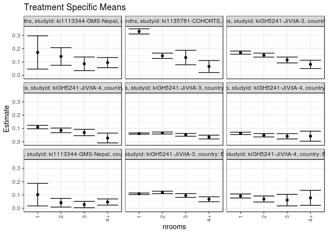

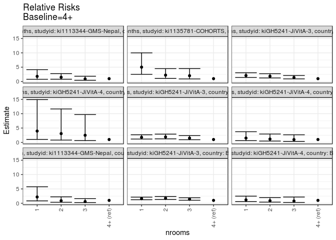

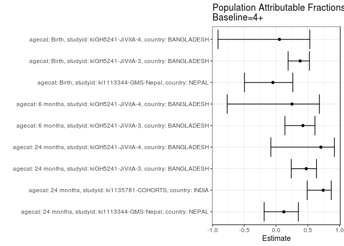

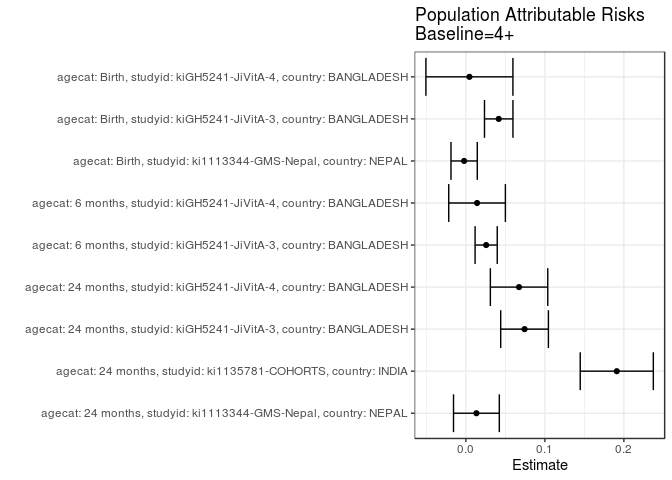

## Results Table

### Parameter: TSM

| agecat | studyid | country | intervention_level | baseline_level | estimate | ci_lower | ci_upper |
| --- | --- | --- | --- | --- | --- | --- | --- |
| Birth | ki1113344-GMS-Nepal | NEPAL | 4+ | NA | 0.0467290 | 0.0236238 | 0.0698341 |
| Birth | ki1113344-GMS-Nepal | NEPAL | 1 | NA | 0.1020408 | 0.0172249 | 0.1868568 |
| Birth | ki1113344-GMS-Nepal | NEPAL | 2 | NA | 0.0413793 | 0.0089385 | 0.0738201 |
| Birth | ki1113344-GMS-Nepal | NEPAL | 3 | NA | 0.0276243 | 0.0037306 | 0.0515180 |
| Birth | kiGH5241-JiVitA-3 | BANGLADESH | 4+ | NA | 0.0675497 | 0.0488611 | 0.0862383 |
| Birth | kiGH5241-JiVitA-3 | BANGLADESH | 1 | NA | 0.1091665 | 0.1035891 | 0.1147440 |
| Birth | kiGH5241-JiVitA-3 | BANGLADESH | 2 | NA | 0.1187137 | 0.1094388 | 0.1279885 |
| Birth | kiGH5241-JiVitA-3 | BANGLADESH | 3 | NA | 0.0959703 | 0.0818019 | 0.1101387 |
| Birth | kiGH5241-JiVitA-4 | BANGLADESH | 4+ | NA | 0.0781250 | 0.0217735 | 0.1344765 |
| Birth | kiGH5241-JiVitA-4 | BANGLADESH | 1 | NA | 0.0920821 | 0.0768029 | 0.1073613 |
| Birth | kiGH5241-JiVitA-4 | BANGLADESH | 2 | NA | 0.0691114 | 0.0465583 | 0.0916646 |
| Birth | kiGH5241-JiVitA-4 | BANGLADESH | 3 | NA | 0.0611511 | 0.0176457 | 0.1046565 |
| 6 months | kiGH5241-JiVitA-3 | BANGLADESH | 4+ | NA | 0.0349463 | 0.0207103 | 0.0491822 |
| 6 months | kiGH5241-JiVitA-3 | BANGLADESH | 1 | NA | 0.0615065 | 0.0566251 | 0.0663879 |
| 6 months | kiGH5241-JiVitA-3 | BANGLADESH | 2 | NA | 0.0660338 | 0.0584520 | 0.0736155 |
| 6 months | kiGH5241-JiVitA-3 | BANGLADESH | 3 | NA | 0.0520402 | 0.0413116 | 0.0627689 |
| 6 months | kiGH5241-JiVitA-4 | BANGLADESH | 4+ | NA | 0.0419847 | 0.0044573 | 0.0795122 |
| 6 months | kiGH5241-JiVitA-4 | BANGLADESH | 1 | NA | 0.0631579 | 0.0545586 | 0.0717572 |
| 6 months | kiGH5241-JiVitA-4 | BANGLADESH | 2 | NA | 0.0489796 | 0.0361264 | 0.0618328 |
| 6 months | kiGH5241-JiVitA-4 | BANGLADESH | 3 | NA | 0.0409836 | 0.0208972 | 0.0610701 |
| 24 months | ki1113344-GMS-Nepal | NEPAL | 4+ | NA | 0.0952381 | 0.0573450 | 0.1331312 |
| 24 months | ki1113344-GMS-Nepal | NEPAL | 1 | NA | 0.1714286 | 0.0464412 | 0.2964159 |
| 24 months | ki1113344-GMS-Nepal | NEPAL | 2 | NA | 0.1415094 | 0.0750891 | 0.2079298 |
| 24 months | ki1113344-GMS-Nepal | NEPAL | 3 | NA | 0.0862069 | 0.0350788 | 0.1373350 |
| 24 months | ki1135781-COHORTS | INDIA | 4+ | NA | 0.0657895 | 0.0205512 | 0.1110277 |
| 24 months | ki1135781-COHORTS | INDIA | 1 | NA | 0.3297086 | 0.3104894 | 0.3489277 |
| 24 months | ki1135781-COHORTS | INDIA | 2 | NA | 0.1466011 | 0.1267588 | 0.1664435 |
| 24 months | ki1135781-COHORTS | INDIA | 3 | NA | 0.1333333 | 0.0789262 | 0.1877405 |
| 24 months | kiGH5241-JiVitA-3 | BANGLADESH | 4+ | NA | 0.0817439 | 0.0505877 | 0.1129001 |
| 24 months | kiGH5241-JiVitA-3 | BANGLADESH | 1 | NA | 0.1702633 | 0.1583007 | 0.1822259 |
| 24 months | kiGH5241-JiVitA-3 | BANGLADESH | 2 | NA | 0.1512500 | 0.1363067 | 0.1661933 |
| 24 months | kiGH5241-JiVitA-3 | BANGLADESH | 3 | NA | 0.1147132 | 0.0926184 | 0.1368080 |
| 24 months | kiGH5241-JiVitA-4 | BANGLADESH | 4+ | NA | 0.0278884 | -0.0089281 | 0.0647049 |
| 24 months | kiGH5241-JiVitA-4 | BANGLADESH | 1 | NA | 0.1100753 | 0.0970601 | 0.1230905 |
| 24 months | kiGH5241-JiVitA-4 | BANGLADESH | 2 | NA | 0.0855263 | 0.0679585 | 0.1030942 |
| 24 months | kiGH5241-JiVitA-4 | BANGLADESH | 3 | NA | 0.0692464 | 0.0454346 | 0.0930583 |

### Parameter: E(Y)

| agecat | studyid | country | intervention_level | baseline_level | estimate | ci_lower | ci_upper |
| --- | --- | --- | --- | --- | --- | --- | --- |
| Birth | ki1113344-GMS-Nepal | NEPAL | NA | NA | 0.0445402 | 0.0292033 | 0.0598771 |
| Birth | kiGH5241-JiVitA-3 | BANGLADESH | NA | NA | 0.1091444 | 0.1045855 | 0.1137033 |
| Birth | kiGH5241-JiVitA-4 | BANGLADESH | NA | NA | 0.0826241 | 0.0709364 | 0.0943118 |
| 6 months | kiGH5241-JiVitA-3 | BANGLADESH | NA | NA | 0.0606548 | 0.0568001 | 0.0645094 |
| 6 months | kiGH5241-JiVitA-4 | BANGLADESH | NA | NA | 0.0561658 | 0.0493946 | 0.0629370 |
| 24 months | ki1113344-GMS-Nepal | NEPAL | NA | NA | 0.1086066 | 0.0809724 | 0.1362407 |
| 24 months | ki1135781-COHORTS | INDIA | NA | NA | 0.2568073 | 0.2428154 | 0.2707992 |
| 24 months | kiGH5241-JiVitA-3 | BANGLADESH | NA | NA | 0.1560325 | 0.1472890 | 0.1647760 |
| 24 months | kiGH5241-JiVitA-4 | BANGLADESH | NA | NA | 0.0952180 | 0.0856733 | 0.1047628 |

### Parameter: RR

| agecat | studyid | country | intervention_level | baseline_level | estimate | ci_lower | ci_upper |
| --- | --- | --- | --- | --- | --- | --- | --- |
| Birth | ki1113344-GMS-Nepal | NEPAL | 4+ | 4+ | 1.0000000 | 1.0000000 | 1.000000 |
| Birth | ki1113344-GMS-Nepal | NEPAL | 1 | 4+ | 2.1836735 | 0.8301606 | 5.743984 |
| Birth | ki1113344-GMS-Nepal | NEPAL | 2 | 4+ | 0.8855172 | 0.3504743 | 2.237370 |
| Birth | ki1113344-GMS-Nepal | NEPAL | 3 | 4+ | 0.5911602 | 0.2182807 | 1.601014 |
| Birth | kiGH5241-JiVitA-3 | BANGLADESH | 4+ | 4+ | 1.0000000 | 1.0000000 | 1.000000 |
| Birth | kiGH5241-JiVitA-3 | BANGLADESH | 1 | 4+ | 1.6160930 | 1.2279009 | 2.127009 |
| Birth | kiGH5241-JiVitA-3 | BANGLADESH | 2 | 4+ | 1.7574276 | 1.3197235 | 2.340302 |
| Birth | kiGH5241-JiVitA-3 | BANGLADESH | 3 | 4+ | 1.4207369 | 1.0488317 | 1.924516 |
| Birth | kiGH5241-JiVitA-4 | BANGLADESH | 4+ | 4+ | 1.0000000 | 1.0000000 | 1.000000 |
| Birth | kiGH5241-JiVitA-4 | BANGLADESH | 1 | 4+ | 1.1786510 | 0.5627810 | 2.468488 |
| Birth | kiGH5241-JiVitA-4 | BANGLADESH | 2 | 4+ | 0.8846262 | 0.3994654 | 1.959027 |
| Birth | kiGH5241-JiVitA-4 | BANGLADESH | 3 | 4+ | 0.7827338 | 0.2825358 | 2.168477 |
| 6 months | kiGH5241-JiVitA-3 | BANGLADESH | 4+ | 4+ | 1.0000000 | 1.0000000 | 1.000000 |
| 6 months | kiGH5241-JiVitA-3 | BANGLADESH | 1 | 4+ | 1.7600306 | 1.1656201 | 2.657562 |
| 6 months | kiGH5241-JiVitA-3 | BANGLADESH | 2 | 4+ | 1.8895799 | 1.2408425 | 2.877490 |
| 6 months | kiGH5241-JiVitA-3 | BANGLADESH | 3 | 4+ | 1.4891496 | 0.9355442 | 2.370349 |
| 6 months | kiGH5241-JiVitA-4 | BANGLADESH | 4+ | 4+ | 1.0000000 | 1.0000000 | 1.000000 |
| 6 months | kiGH5241-JiVitA-4 | BANGLADESH | 1 | 4+ | 1.5043061 | 0.6082917 | 3.720151 |
| 6 months | kiGH5241-JiVitA-4 | BANGLADESH | 2 | 4+ | 1.1666047 | 0.4662135 | 2.919192 |
| 6 months | kiGH5241-JiVitA-4 | BANGLADESH | 3 | 4+ | 0.9761550 | 0.3592073 | 2.652726 |
| 24 months | ki1113344-GMS-Nepal | NEPAL | 4+ | 4+ | 1.0000000 | 1.0000000 | 1.000000 |
| 24 months | ki1113344-GMS-Nepal | NEPAL | 1 | 4+ | 1.8000000 | 0.7844243 | 4.130418 |
| 24 months | ki1113344-GMS-Nepal | NEPAL | 2 | 4+ | 1.4858491 | 0.8030562 | 2.749182 |
| 24 months | ki1113344-GMS-Nepal | NEPAL | 3 | 4+ | 0.9051724 | 0.4431652 | 1.848830 |
| 24 months | ki1135781-COHORTS | INDIA | 4+ | 4+ | 1.0000000 | 1.0000000 | 1.000000 |
| 24 months | ki1135781-COHORTS | INDIA | 1 | 4+ | 5.0115702 | 2.5134637 | 9.992520 |
| 24 months | ki1135781-COHORTS | INDIA | 2 | 4+ | 2.2283374 | 1.1056576 | 4.490981 |
| 24 months | ki1135781-COHORTS | INDIA | 3 | 4+ | 2.0266667 | 0.9110212 | 4.508542 |
| 24 months | kiGH5241-JiVitA-3 | BANGLADESH | 4+ | 4+ | 1.0000000 | 1.0000000 | 1.000000 |
| 24 months | kiGH5241-JiVitA-3 | BANGLADESH | 1 | 4+ | 2.0828868 | 1.4194951 | 3.056310 |
| 24 months | kiGH5241-JiVitA-3 | BANGLADESH | 2 | 4+ | 1.8502907 | 1.2550249 | 2.727895 |
| 24 months | kiGH5241-JiVitA-3 | BANGLADESH | 3 | 4+ | 1.4033243 | 0.9342664 | 2.107877 |
| 24 months | kiGH5241-JiVitA-4 | BANGLADESH | 4+ | 4+ | 1.0000000 | 1.0000000 | 1.000000 |
| 24 months | kiGH5241-JiVitA-4 | BANGLADESH | 1 | 4+ | 3.9469856 | 1.0452081 | 14.904874 |
| 24 months | kiGH5241-JiVitA-4 | BANGLADESH | 2 | 4+ | 3.0667293 | 0.8069311 | 11.655059 |
| 24 months | kiGH5241-JiVitA-4 | BANGLADESH | 3 | 4+ | 2.4829793 | 0.6354707 | 9.701764 |

### Parameter: PAR

| agecat | studyid | country | intervention_level | baseline_level | estimate | ci_lower | ci_upper |
| --- | --- | --- | --- | --- | --- | --- | --- |
| Birth | ki1113344-GMS-Nepal | NEPAL | 4+ | NA | -0.0021887 | -0.0188213 | 0.0144438 |
| Birth | kiGH5241-JiVitA-3 | BANGLADESH | 4+ | NA | 0.0415947 | 0.0235820 | 0.0596075 |
| Birth | kiGH5241-JiVitA-4 | BANGLADESH | 4+ | NA | 0.0044991 | -0.0505658 | 0.0595640 |
| 6 months | kiGH5241-JiVitA-3 | BANGLADESH | 4+ | NA | 0.0257085 | 0.0116930 | 0.0397240 |
| 6 months | kiGH5241-JiVitA-4 | BANGLADESH | 4+ | NA | 0.0141811 | -0.0216765 | 0.0500386 |
| 24 months | ki1113344-GMS-Nepal | NEPAL | 4+ | NA | 0.0133685 | -0.0156169 | 0.0423538 |
| 24 months | ki1135781-COHORTS | INDIA | 4+ | NA | 0.1910178 | 0.1447582 | 0.2372773 |
| 24 months | kiGH5241-JiVitA-3 | BANGLADESH | 4+ | NA | 0.0742886 | 0.0440967 | 0.1044805 |
| 24 months | kiGH5241-JiVitA-4 | BANGLADESH | 4+ | NA | 0.0673296 | 0.0310038 | 0.1036554 |

### Parameter: PAF

| agecat | studyid | country | intervention_level | baseline_level | estimate | ci_lower | ci_upper |
| --- | --- | --- | --- | --- | --- | --- | --- |
| Birth | ki1113344-GMS-Nepal | NEPAL | 4+ | NA | -0.0491408 | -0.4971711 | 0.2648159 |
| Birth | kiGH5241-JiVitA-3 | BANGLADESH | 4+ | NA | 0.3810982 | 0.1904569 | 0.5268449 |
| Birth | kiGH5241-JiVitA-4 | BANGLADESH | 4+ | NA | 0.0544528 | -0.9134904 | 0.5327599 |
| 6 months | kiGH5241-JiVitA-3 | BANGLADESH | 4+ | NA | 0.4238496 | 0.1404429 | 0.6138136 |
| 6 months | kiGH5241-JiVitA-4 | BANGLADESH | 4+ | NA | 0.2524858 | -0.7690276 | 0.6841330 |
| 24 months | ki1113344-GMS-Nepal | NEPAL | 4+ | NA | 0.1230907 | -0.1868964 | 0.3521171 |
| 24 months | ki1135781-COHORTS | INDIA | 4+ | NA | 0.7438177 | 0.4916036 | 0.8709091 |
| 24 months | kiGH5241-JiVitA-3 | BANGLADESH | 4+ | NA | 0.4761097 | 0.2406458 | 0.6385598 |
| 24 months | kiGH5241-JiVitA-4 | BANGLADESH | 4+ | NA | 0.7071096 | -0.0808982 | 0.9206357 |